# (Prosper EDA)

### Borrower APR vs Prosper Rating & Credit Grade.

During the company's first iteration, Credit Grade was chosen as the metric that helps investors pick their listing. However, this metric evolved to be Prosper Rating in the 2nd iteration of the company. It's expected that higher Credit Grade (Prosper Rating) negatively correlates with Borrower APR, but I'll check this relationship with a graph.

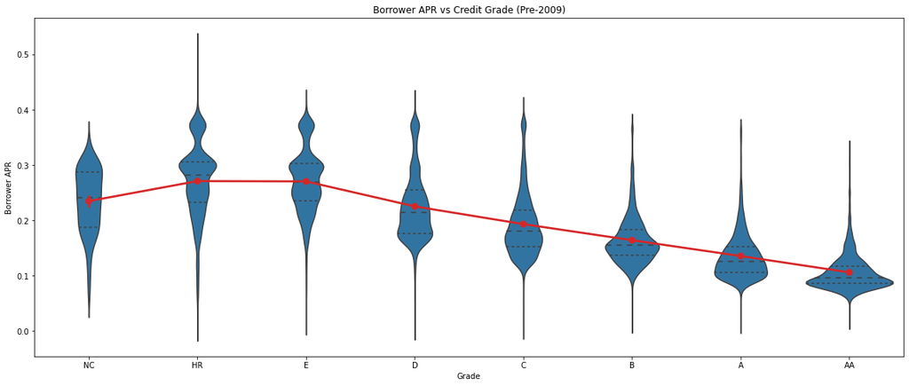

```python
base_color = sb.color_palette()[0]
plt.figure(figsize=[20, 8])
sb.violinplot(data=prosper_01,
             x='CreditGrade',
             y='BorrowerAPR',
             color=base_color,
             inner='quartile');
plt.xlabel('Grade')
plt.ylabel('Borrower APR')
plt.title('Borrower APR vs Credit Grade (Pre-2009)')

base_color = sb.color_palette()[3]
sb.pointplot(data=prosper_01,
             x='CreditGrade',
             y='BorrowerAPR',
             color=base_color,
             ci=95,
             linestyles='-',
             estimator=np.mean)
plt.xlabel('Grade')
plt.ylabel('Borrower APR')

plt.show();
```

- There is a general trend when Credit Grade increases, the median borrower APR decreases. However if we drew a line connecting Grade means, it will have a very gentle slope.
- Outliers break this general trend.
- For the lowest 3 grades (NC (No Credit), HR, E), the median rate is nearly identical.
- NC grade has broad distributions. HR and E grades have many peaks as well.
- D and C grades have wide variances.
- Difference between B and A grades is where their peaks lie. However, they can be matching for large portions of time.

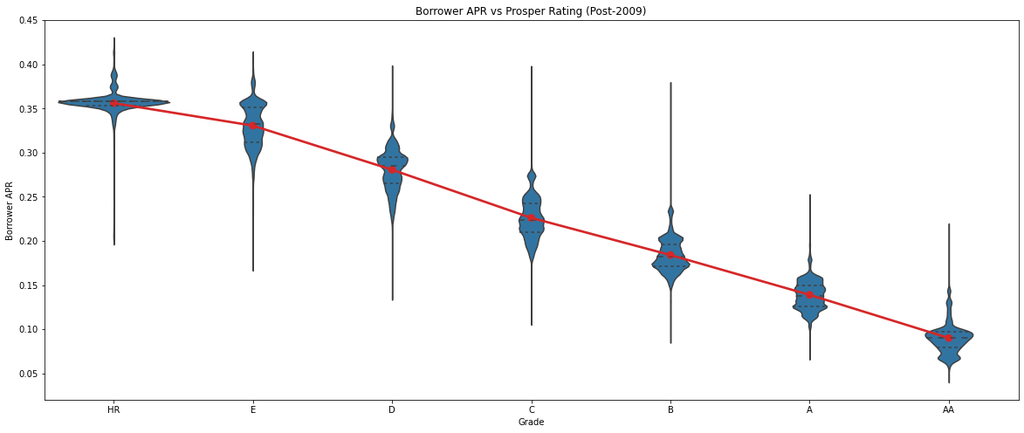

```python
base_color = sb.color_palette()[0]
plt.figure(figsize=[20, 8])
sb.violinplot(data=prosper_02,
             x='ProsperRating',
             y='BorrowerAPR',
             color=base_color,
             inner='quartile');
plt.xlabel('Rating')
plt.ylabel('Borrower APR')
plt.title('Borrower APR vs Prosper Rating (Post-2009)')

base_color = sb.color_palette()[3]
sb.pointplot(data=prosper_02,
             x='ProsperRating',
             y='BorrowerAPR',
             color=base_color,
             ci=95,
             linestyles='-',
             estimator=np.mean)
plt.xlabel('Grade')
plt.ylabel('Borrower APR')

plt.show();
```

- The trend is much cleare now, proving that their new model is more refined.
- The general trend proves what's expected. As Prosper Rating increases, the median Borrower APR decreases. If we drew a slope connecting rating means, we would get a steep slope.
- However, there are outliers that kind of break the general trend.
- Although A ratings are 2nd best, they are more broadly distributed than AA.
- The distribution for HR is most peaked at 0.36 rate.
- E ratings have broad distributions and one of the peaks is equivalent to the mean of HR ratings.
- The variance in middle ratings (B, C, D) is great and shouldn't be underestimated. Outliers in B and C ratings tend to have higher rates.

### Prosper Score and Average Credit Score Vs. Borrower APR

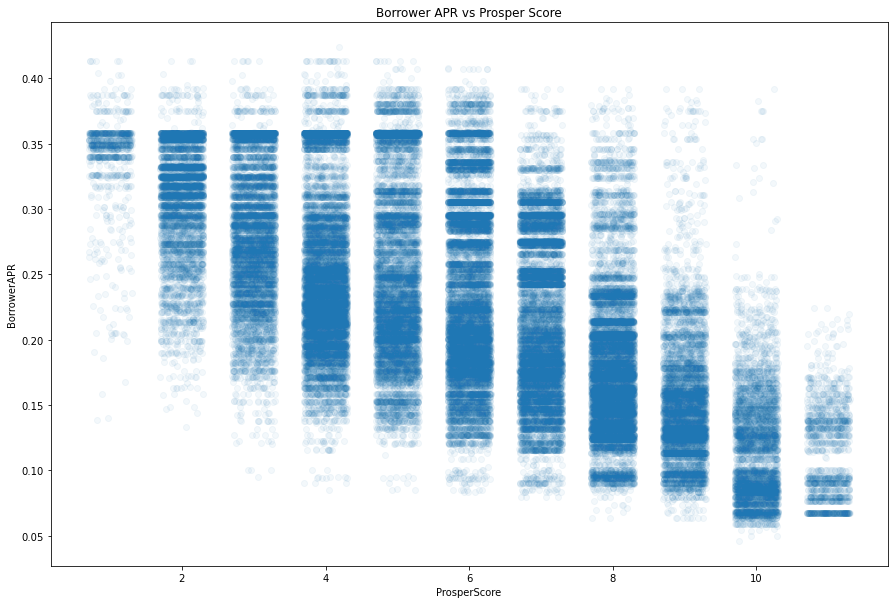

```python
plt.figure(figsize=[15, 10])
sb.regplot(data=prosper_02,
           x='ProsperScore',
           y='BorrowerAPR',
           truncate=False,
           x_jitter=0.3,
           scatter_kws={'alpha': 1/20}, fit_reg=False);
plt.title('Borrower APR vs Prosper Score')
```

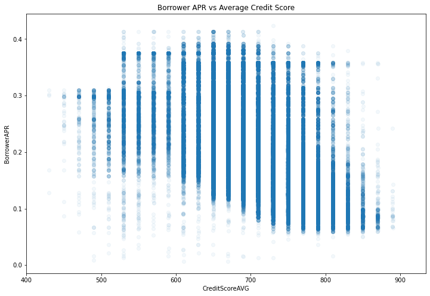

```python
plt.figure(figsize=[12, 8])
sb.regplot(data=prosper_clean,
           x='CreditScoreAVG',
           y='BorrowerAPR',
           truncate=False,
           x_jitter=0.3,
           scatter_kws={'alpha': 1/20}, fit_reg=False);
plt.title('Borrower APR vs Average Credit Score')
plt.xlim(400, );
```

The negative correlation between Borrower APR and Average Credit Score is more subtle than it's between Borrower APR and Prosper Score

### Factors Affecting Prosper Rating

As previously explained, in the company's second iteration Prosper Ratings are based on two factors, Prosper Score and Credit Score.

### Prosper Score & Credit Score

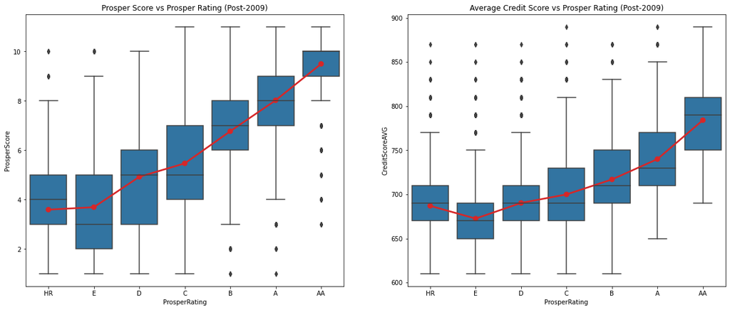

```python
plt.figure(figsize=[20, 8])
plt.subplot(1, 2, 1)
base_color = sb.color_palette()[0]
sb.boxplot(data=prosper_02,
              x='ProsperRating',
              y='ProsperScore',
              color=base_color);
plt.xlabel('Rating')
plt.ylabel('Score')
plt.title('Prosper Score vs Prosper Rating (Post-2009)');

base_color = sb.color_palette()[3]
sb.pointplot(data=prosper_02,
             x='ProsperRating',
             y='ProsperScore',
             color=base_color,
             ci=95,
             linestyles='-',
             estimator=np.mean)

plt.subplot(1, 2, 2)
base_color = sb.color_palette()[0]
sb.boxplot(data=prosper_02,
              x='ProsperRating',
              y='CreditScoreAVG',
              color=base_color);
plt.xlabel('Rating')
plt.ylabel('Average Credit Score')
plt.title('Average Credit Score vs Prosper Rating (Post-2009)');

base_color = sb.color_palette()[3]
sb.pointplot(data=prosper_02,
             x='ProsperRating',
             y='CreditScoreAVG',
             color=base_color,
             ci=95,
             linestyles='-',
             estimator=np.mean)
plt.show();
```

- Connecting ratings' average Prosper Scores result in a strong positive correlation.
- Connecting each rating collective Average Credit Scores result in a moderately strong positive correlation.
- Prosper Ratings are more affected by Prosper Score than by Borrowers' Credit Scores.
- This shows that Prosper weighs in their own data more favorably over external sources.

#### Credit Inquiries, Delinquincies, and Trades Opened vs Prosper Score

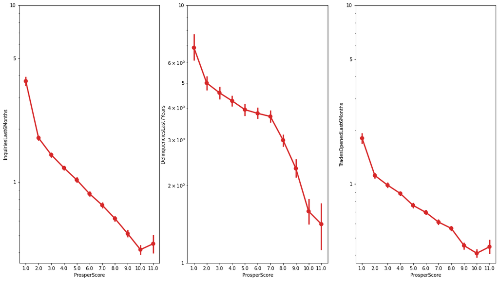

```python
plt.figure(figsize=[18, 10])
#  point plot of the average number of credit inquiries vs Prosper Score
ax1 = plt.subplot(1, 3, 1)
base_color = sb.color_palette()[3]
sb.pointplot(data=prosper_02,
             x='ProsperScore',
             y='InquiriesLast6Months',
             color=base_color,
             ci=95,
             linestyles='-',
             estimator=np.mean)
#  log-scale is chosen for clarification purposes
ax1.set_yscale('log')
ax1.set_yticks(ticks=[1, 5, 10])
ax1.set_yticklabels(labels=['1', '5', '10'])

#  Delinquinces
ax2 = plt.subplot(1, 3, 2)
base_color = sb.color_palette()[3]
sb.pointplot(data=prosper_02,
           x='ProsperScore',
           y='DelinquenciesLast7Years',
           color=base_color,
           ci=95,
           linestyles='-',
           estimator=np.mean);
#  log-scale is chosen for clarification purposes
ax2.set_yscale('log')
ax2.set_yticks(ticks=[1, 5, 10])
ax2.set_yticklabels(labels=['1', '5', '10'])

#  Public Records
ax3 = plt.subplot(1, 3, 3)
base_color = sb.color_palette()[3]
sb.pointplot(data=prosper_02,
           x='ProsperScore',
           y='TradesOpenedLast6Months',
           color=base_color,
           ci=95,
           linestyles='-',
           estimator=np.mean);
#  log-scale is chosen for clarification purposes
ax3.set_yscale('log')
ax3.set_yticks(ticks=[1, 5, 10])
ax3.set_yticklabels(labels=['1', '5', '10'])
plt.show();
```

- It's clear that in order for the borrower's Prosper Score to increase by 1, the average number of inquiries and trades opened has to decrease except for the transition from a score of 10 to 11.
- Decreasing the number of Delinquencies in borrower's credit record helps especially for Prosper scores above 7. Then each increment in Prosper Score requires a significant decrease in number of Delinquencies.

#### ScoreX Change, Available Bank Card Credit vs Prosper Score

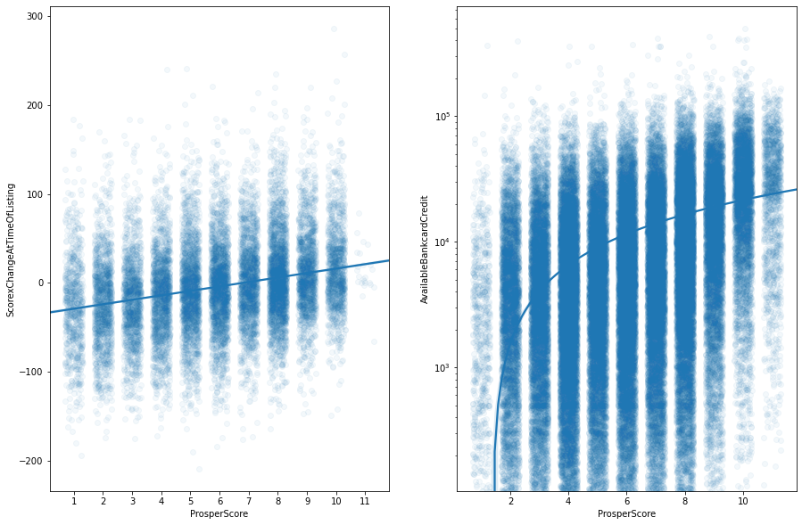

```python
plt.figure(figsize=[15, 10])

#  ScoreX change
ax1 = plt.subplot(1, 2, 1)
sb.regplot(data=prosper_02,
           x='ProsperScore',
           y='ScorexChangeAtTimeOfListing',
           truncate=False,
           x_jitter=0.3,
           scatter_kws={'alpha': 1/20});
ax1.set_xticks(ticks=np.arange(1, 12, 1))
ax1.set_xticklabels(labels=[str(int(i)) for i in np.arange(1, 12, 1)])

#  Available Credit
ax2 = plt.subplot(1, 2, 2)
sb.regplot(data=prosper_02,
           x='ProsperScore',
           y='AvailableBankcardCredit',
           truncate=False,
           x_jitter=0.3,
           scatter_kws={'alpha': 1/20});
ax2.set_yscale('log')
plt.show();
```

- There is a clear positive linear correlation between Credit Change and Prosper Score.
- On log-scale, it takes a significant change in Bank Credit to increas Prosper Score from 1 to 2. Prosper Scores beyond 2 exhibits a strong linear relationship between Prosper Scale and the log10 of Available Bank Card Credit.

#### Debt/Income and Monthly Income vs Prosper Score

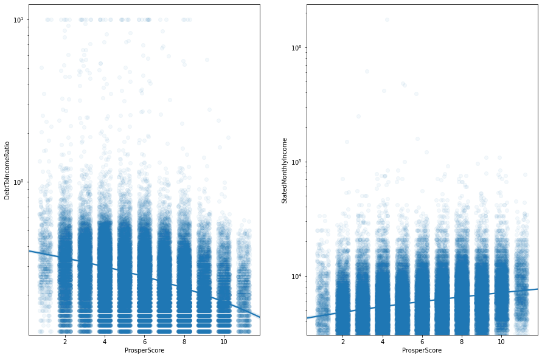

```python
plt.figure(figsize=[15, 10])
ax2 = plt.subplot(1, 2, 2)
sb.regplot(data=prosper_02,
           x='ProsperScore',
           y='StatedMonthlyIncome',
           truncate=False,
           x_jitter=0.3,
           scatter_kws={'alpha': 1/20});
ax2.set_yscale('log')
ax1 = plt.subplot(1, 2, 1)
sb.regplot(data=prosper_02,
           x='ProsperScore',
           y='DebtToIncomeRatio',
           truncate=False,
           x_jitter=0.3,
           scatter_kws={'alpha': 1/20});
ax1.set_yscale('log')
```

- As expected, Prosper Score improves with decreasing Debt/Income and increasing Monthly Income to a lesser degree.

#### Loan Amount and Recommendations vs Borrower APR

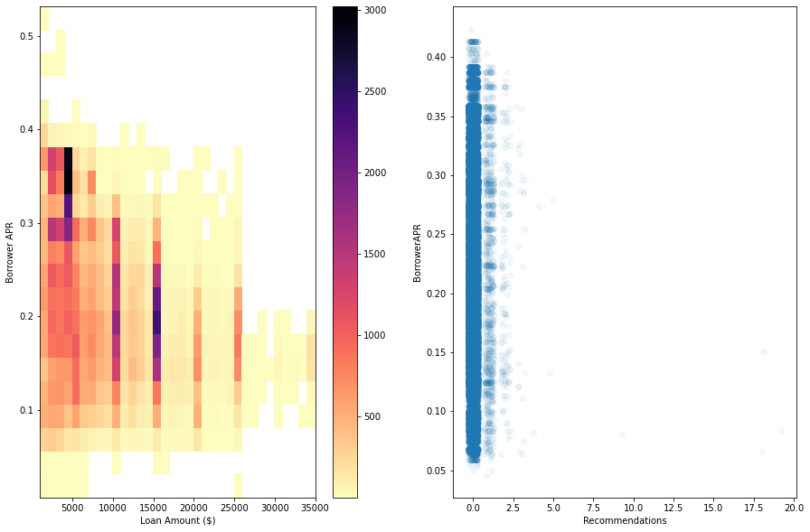

```python
plt.figure(figsize=[15, 10])
ax1 = plt.subplot(1, 2, 1)

x_bins = np.arange(prosper_clean['LoanOriginalAmount'].min(), prosper_clean['LoanOriginalAmount'].max()+1000, 1000)
y_bins = np.arange(prosper_clean['BorrowerAPR'].min(), prosper_clean['BorrowerAPR'].max()+0.025, 0.025)
plt.hist2d(data=prosper_clean,
           x='LoanOriginalAmount',
           y='BorrowerAPR',
           cmin=0.5,
           cmap='magma_r',
           bins=[x_bins, y_bins]);
plt.colorbar();
ax1.set_xlabel('Loan Amount ($)')
ax1.set_ylabel('Borrower APR')
ax2 = plt.subplot(1, 2, 2)
sb.regplot(data=prosper_02,
           x='Recommendations',
           y='BorrowerAPR',
           truncate=False,
           x_jitter=0.3,
           scatter_kws={'alpha': 1/20},
           fit_reg=False);
```

- The general trend for Borrower APR is to decrease with increasing Loan Amount. However, there still exists a great variance in the Borrowe APR for the some Loan Amounts, especially for small Loans (<5k).
- Getting recommendations have no effect on Borrower APR.

#### BorrowerAPR over the years

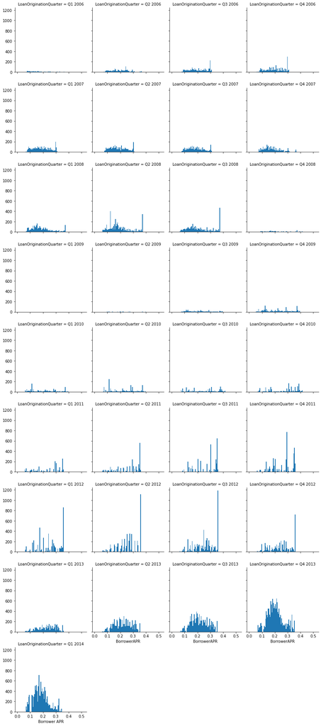

```python
#  Faceting histograms of BorrowerRate against levels of OriginationQuarter
g = sb.FacetGrid(data=prosper_clean,
                 col='LoanOriginationQuarter',
                 col_wrap=4,
                 sharey=True)
binsize = 0.005
bins = np.arange(prosper_clean['BorrowerAPR'].min(),
                 prosper_clean['BorrowerAPR'].max()+binsize,
                 binsize)
g.map(plt.hist,
      'BorrowerAPR',
      bins=bins);
plt.xlabel('Borrower APR');
```

- During year 2008, Borrower APR hit the roof during company's 1st iteration. (Reasonable during the economic crisis)
- Borrower APR started to rise once again on 2nd quarter of 2011 until 4th quarter of 2012. Then eased off until it reached reasonable amount within the normal distribution. Maybe it's related to post-recession period.

#### BorrowerAPR with Loan Status

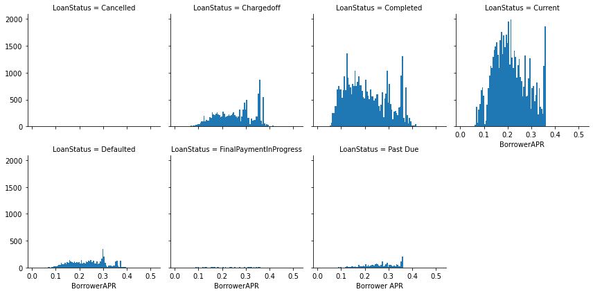

```python
#  Faceting histograms of BorrowerRate against levels of LoanStatus
g = sb.FacetGrid(data=prosper_clean,
                 col='LoanStatus',
                 col_wrap=4,
                 sharey=True)
binsize = 0.005
bins = np.arange(prosper_clean['BorrowerAPR'].min(),
                 prosper_clean['BorrowerAPR'].max()+binsize,
                 binsize)
g.map(plt.hist,
      'BorrowerAPR',
      bins=bins);
plt.xlabel('Borrower APR');
```

Borrowe APR >=0.3 gets completed more often than not, but the possibility of a loan to get (charged-off, defaulted, or past-due) cannot be underestimated.

## Bivariate Analysis

### Prosper Iterations

Company's first iteration showed a moderate weak correlation between Credit Grade and Borrower APR. After applying the new model in the third quarter of 2009, Prosper Rating became a more refined metric for Borrower APR.

### Borrower APR Controlling Factor

Borrower APR is strongly and negatively correlated with Prosper Rating. Increasing Prosper Rating, guarantees lower Borrower APR.

## Multivariate Exploaration

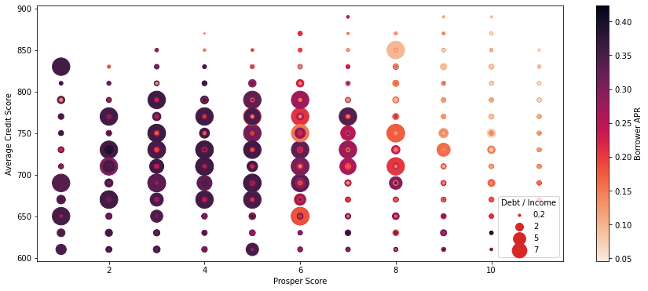

```python
plt.figure(figsize=[15, 6])
plt.scatter(data=prosper_02,
            x='ProsperScore',
            y='CreditScoreAVG',
            c='BorrowerAPR',
            cmap='rocket_r',
            s=prosper_02['DebtToIncomeRatio']*50)
plt.colorbar(label='Borrower APR')
plt.xlabel('Prosper Score')
plt.ylabel('Average Credit Score')

#  add dummy scatter plot sequences to construct our legend

#  pick representative data point sizes
sizes = [0.2, 2, 5, 7]

base_color = sb.color_palette()[3]
#  a list to store all of the dummy scatter plot objects
legend_obj = []
for s in sizes:
    legend_obj.append(plt.scatter(x=[],
                                  y=[],
                                  s=s*50,
                                  color=base_color))

plt.legend(legend_obj,
           sizes,
           title='Debt / Income',
           loc='lower right')
plt.show();
```

- It's clear that having both low Credit Score and Prosper Score, charges the borrower with the highest rate.
- Having a high Credit Score and Prosper Score, guarantees the borrower the lowest rates.
- High Credit Score combined with low Prosper Score (<5) can still charge the borrower with high rates.
- On the other hand, having high Prosper Score but with low Credit Score, borrower is more likely to be charged with low rates. However, there are still exceptions.
- Most of borrowers with high debt-to-income ratio have below average Prosper Score with varying Credit Scores

Prosper Score is the more dominant factor deciding the borrower APR

### Borrower APR Variance with Prosper APR for Each Employment Status Level

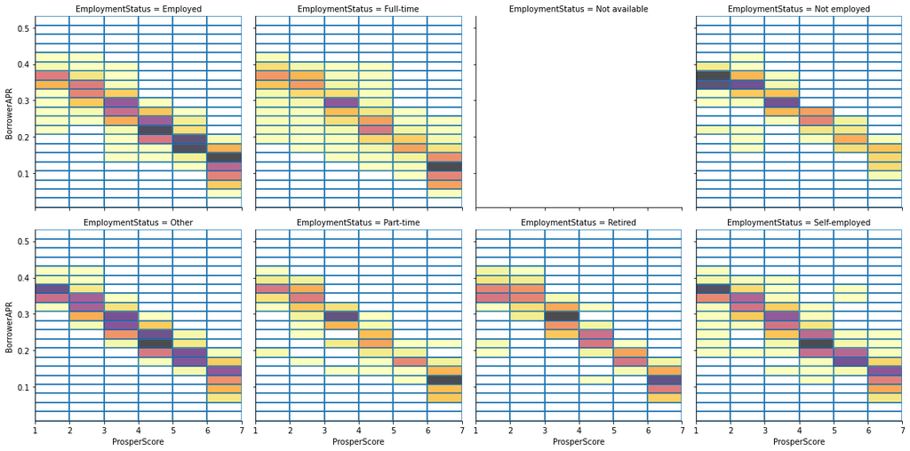

```python
x_bins = np.arange(prosper_clean['ProsperRating (numeric)'].min(), prosper_clean['ProsperRating (numeric)'].max()+1, 1)
y_bins = np.arange(prosper_clean['BorrowerAPR'].min(), prosper_clean['BorrowerAPR'].max()+0.025, 0.025)
g = sb.FacetGrid(data=prosper_clean[prosper_clean['EmploymentStatus']!='Not available'],
                 col='EmploymentStatus',
                 col_wrap = 4,
                 height = 4)
g.map(plt.hist2d,
      'ProsperRating (numeric)',
      'BorrowerAPR',
      cmap='inferno_r',
      cmin=0.001,
      bins=[x_bins, y_bins],
      alpha=0.7)
g.set_xlabels('ProsperScore')
g.set_ylabels('BorrowerAPR');
```